# Problem Set 1

Professor: Dr. Claire Duquennois

**Group Member 1: Chean Shea**

**Group Member 2: Mayowa Idowu**

**Group Member 3: Milan Stefanelli**

**Group Member 4: Kiersten Kochanowski**

Neil’s comments in green

# Omitted Variable Bias Simulation (Group excercise)

```r
 library(MASS)
 library(ggplot2)

out <- as.data.frame(mvrnorm(1000, mu = c(0,0),
                     Sigma = matrix(c(1,0.8,0.8,1), ncol = 2),
                     empirical = TRUE))
cor(out)
```

```
##     V1  V2
## V1 1.0 0.8
## V2 0.8 1.0
```

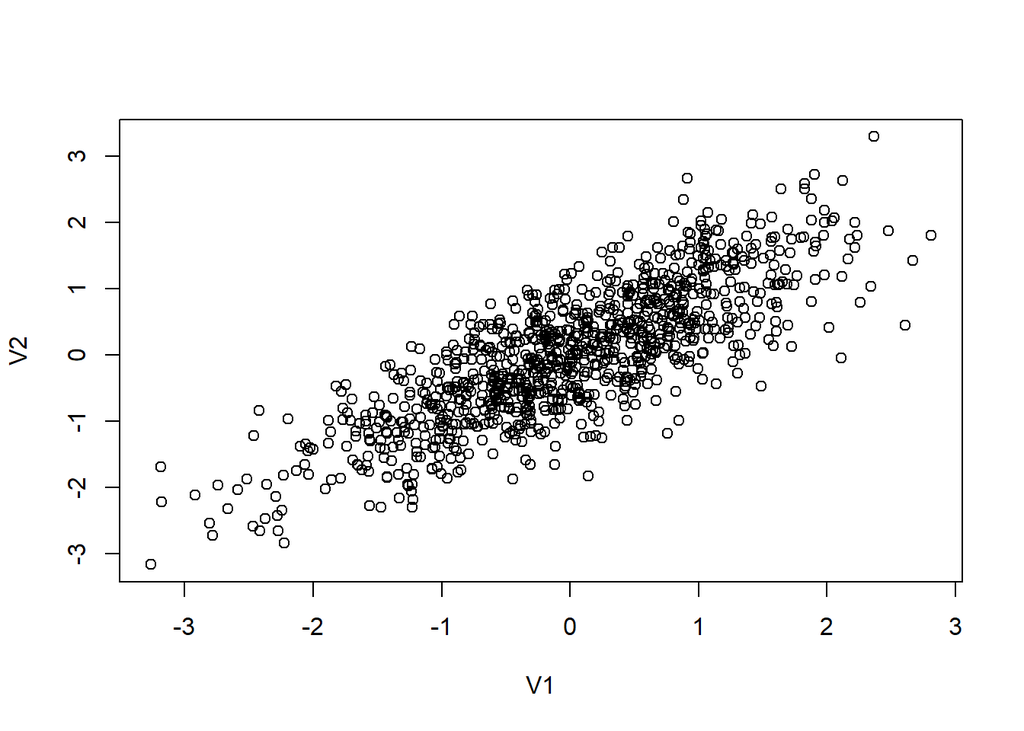

```r
plot(out)
```

Next I generate a randomly distributed error term and I calculate the outcome variable which depends on both V1 and V2 and some noise:

$$Y=\beta_1V_1+\beta_2V_2+\epsilon$$

```r
out$error<-rnorm(1000, mean=0, sd=1)

#The data generating process
B1<-3
B2<-6

out$Y<-out$V1*B1+out$V2*B2+out$error
```

**TO DO: For the questions below write the needed code and a written response to the question.**

**Question 1: Write a chunk in which you regress $Y$ on $V_1$ and $V_2$. Are your estimates of $\beta_1$ and $\beta_2$ biased?**

**Answer:** No, our data was randomly generated (within parameters) so their coefficients are not bias. This is also affirmed by the fact that the V1 and V2 coefficients in our regression model are almost identical to the one B1 and B2 generated above.

```r
View(out)
M1 <- lm(data=out, Y ~ V1 + V2)

stargazer(M1, type="text", header=FALSE, title="Regression Coefficients",
                     style="qje",
                     covariate.labels = c("B1", "B2", "Intercept"),
                     column.labels = c("Model #1"))
```

```
##
## Regression Coefficients
## ==========================================================
##                                       Y
##                                    Model #1
## ----------------------------------------------------------
## B1                                 2.898***
##                                    (0.055)
##
## B2                                 6.069***
##                                    (0.055)
##
## Intercept                           0.001
##                                    (0.033)
##
## N                                   1,000
## R2                                  0.986
## Adjusted R2                         0.986
## Residual Std. Error            1.038 (df = 997)
## F Statistic              33,998.280*** (df = 2; 997)
## ==========================================================
## Notes:              ***Significant at the 1 percent level.
##                      **Significant at the 5 percent level.
##                      *Significant at the 10 percent level.
```

**Question 2: Write a chunk in which you regress $Y$ on $V_1$ only. Is your estimate of $\beta_1$ biased?**

```r
M2 <- lm(data=out, Y~V1)

library(stargazer)
stargazer(M2, M1, type="text", header=FALSE, title="Comparison of Regression Coefficients (M2 & M1)",
                     style="qje",
                     covariate.labels = c("B1", "B2", "Intercept"),
                     column.labels = c("Model #2", "Model #1"))
```

```
##
## Comparison of Regression Coefficients (M2 & M1)
## ==========================================================================
##                                               Y
##                              Model #2                   Model #1
##                                (1)                         (2)
## --------------------------------------------------------------------------
## B1                           7.753***                   2.898***
##                              (0.120)                     (0.055)
##
## B2                                                      6.069***
##                                                          (0.055)
##
## Intercept                     0.001                       0.001
##                              (0.120)                     (0.033)
##
## N                             1,000                       1,000
## R2                            0.807                       0.986
## Adjusted R2                   0.807                       0.986
## Residual Std. Error      3.788 (df = 998)           1.038 (df = 997)
## F Statistic         4,185.437*** (df = 1; 998) 33,998.280*** (df = 2; 997)
## ==========================================================================
## Notes:                              ***Significant at the 1 percent level.
##                                      **Significant at the 5 percent level.
##                                      *Significant at the 10 percent level.
```

**Question 3: Generate a new variable $Y_{adj}$ such that $Y_{adj}=Y-\beta_2*V_2$. Then regress $Y_{adj}$ on $V_1$. Is your estimate of $\beta_1$ biased? Can you explain why/why not?**

Y-B2V2 = B1V1 (Model #3), which is equal to Y=B1V1 + B2V2 (Model #1)

```r
Y_adj <- ((out$Y)-(B2*out$V2))
M3 <- lm(data=out, Y_adj ~ V1)
stargazer(M3, M1, type="text", header=FALSE, title="Comparison of Regression Coefficients (M3 & M1)",
                     style="qje",
                     covariate.labels = c("B1", "B2", "Intercept"),
                     column.labels = c("Model #3", "Model #1"))
```

```
##
## Comparison of Regression Coefficients (M3 & M1)
## ==========================================================================
##                               Y_adj                         Y
##                              Model #3                   Model #1
##                                (1)                         (2)
## --------------------------------------------------------------------------
## B1                           2.953***                   2.898***
##                              (0.033)                     (0.055)
##
## B2                                                      6.069***
##                                                          (0.055)
##
## Intercept                     0.001                       0.001
##                              (0.033)                     (0.033)
##
## N                             1,000                       1,000
## R2                            0.890                       0.986
## Adjusted R2                   0.890                       0.986
## Residual Std. Error      1.039 (df = 998)           1.038 (df = 997)
## F Statistic         8,078.168*** (df = 1; 998) 33,998.280*** (df = 2; 997)
## ==========================================================================
## Notes:                              ***Significant at the 1 percent level.
##                                      **Significant at the 5 percent level.
##                                      *Significant at the 10 percent level.
```

**Question 4: The code below generates a scatter plot and regression line for the relationship between $V_1$ and $Y$ as well as $V_1$ and $Y_{adj}$. Submit an improved visualization of this data. Hint: you will need to delete the # to get the code to run**

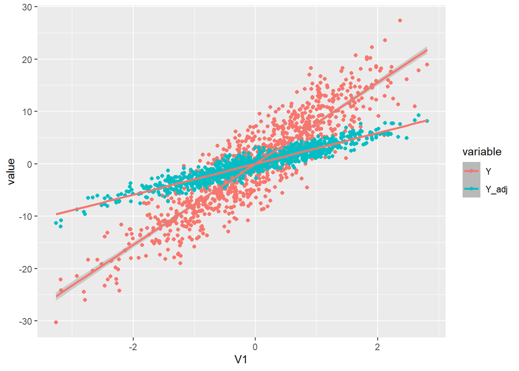

```r
plotted<-ggplot(out, aes(V1, y = value, color = variable)) +
   geom_point(aes(y = Y, col = "Y")) +
   geom_point(aes(y = Y_adj, col = "Y_adj"))+
   geom_smooth(method='lm', aes(y = Y, col = "Y"))+
   geom_smooth(method='lm', aes(y = Y_adj, col = "Y"))

plotted
```

Its best practice to only install packages once. Either do so locally (not included in rmarkdown file) or do so and then comment out. **New Data Visualizations** We interpreted the provided visual to be describing the relationship between V1 and Y with and without omitted variable bias (OVB). Our first visual makes this argument more clear by indicating which LOBF was influenced by OVB, using the same scatter plot method. I’m not following. Cool colors though!

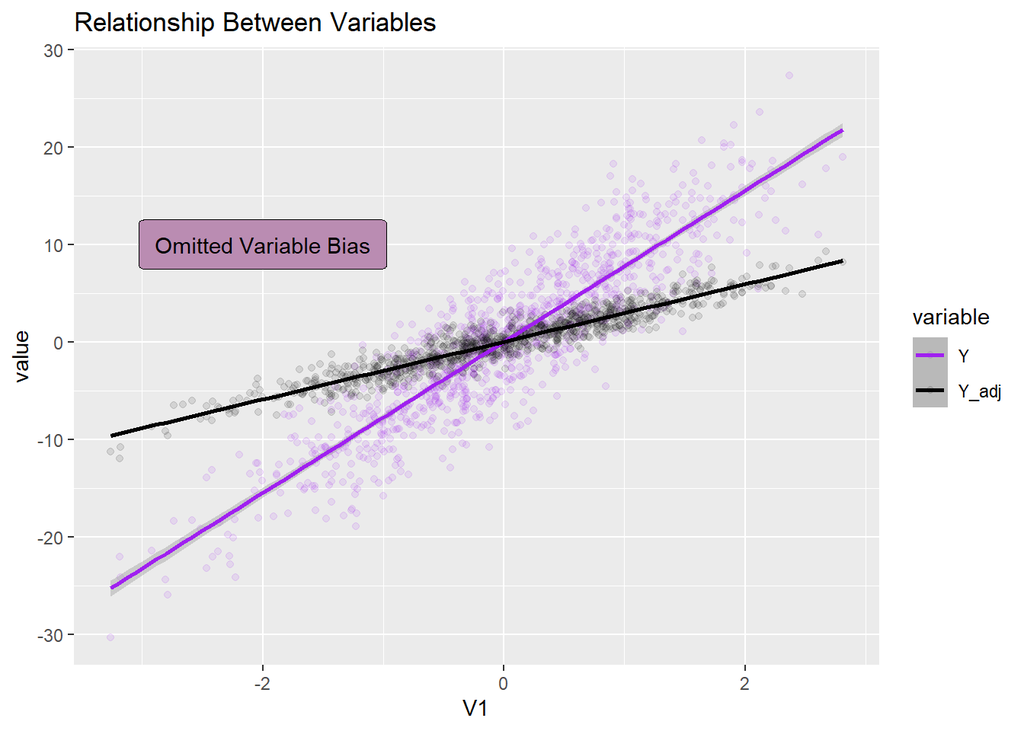

```r
plotted<-ggplot(out, aes(V1, y = value, color = variable)) +
   geom_point(aes(y = Y, col = "Y"), alpha = .1) +
   geom_point(aes(y = Y_adj, col = "Y_adj"), alpha = .1)+
   geom_smooth(method='lm', aes(y = Y, col = "Y"))+
   geom_smooth(method='lm', aes(y = Y_adj, col = "Y_adj")) +
   scale_color_manual(values=c("Purple","Black")) +
   labs(title = "Relationship Between Variables") +
   geom_label(
    label="Omitted Variable Bias",
    x=-2,
    y=10,
    label.padding = unit(0.55, "lines"), # Rectangle size around label
    label.size = 0.35,
    color = "black",
    fill="#BA8CB2"
  )

plotted
```

Our second visual takes an even simpler approach by illustrating the difference in the V1 coefficient (and its relationship to Y) when it is and isn’t biased by missing variable V2.

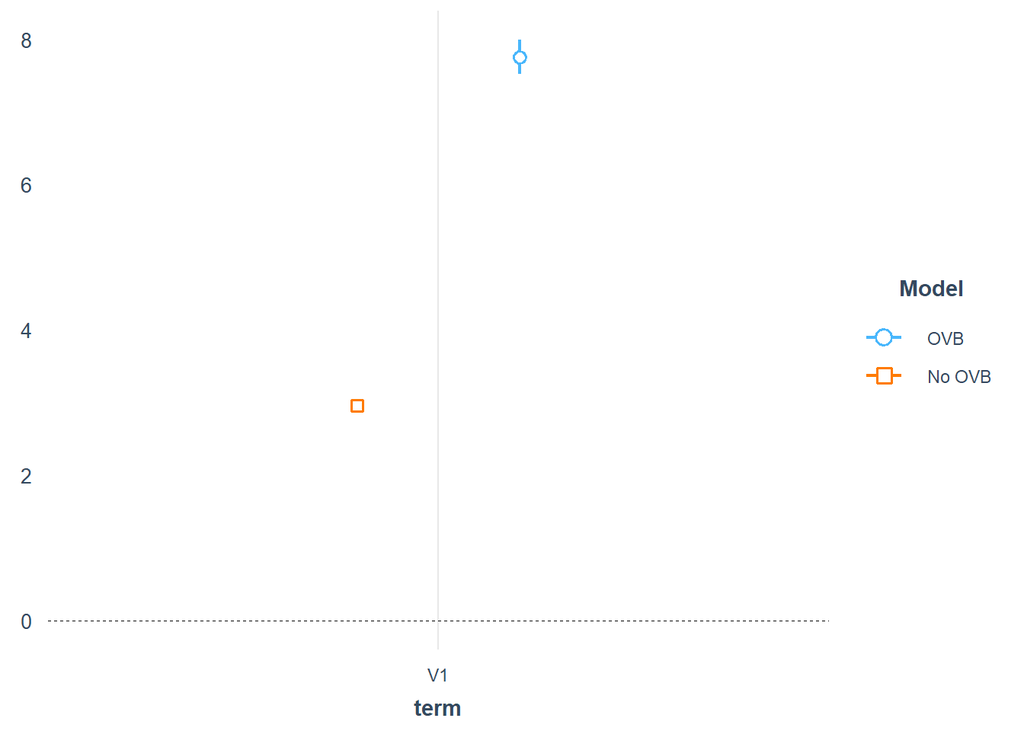

```r
data_vis <- plot_coefs(M2, M3, omit.coefs =c("(Intercept)","V2"), model.names=c("OVB", "No OVB"))
data_vis2 <- data_vis + coord_flip()
data_vis2
```

Something to think about: is there an advantage to this figure over just looking at the regression coefficients?